# Differential Expression Analysis

ALSF CCDL - Candace Savonen

*Purpose*: This notebook takes data and metadata from refine.bio and identifies differentially expressed genes. This script is very generally applicable to pre-processed RNA-Seq or microarray data.

## 1) Install libraries

This script uses the bioconductor R package limma to identify differentially expressed genes.  
The full guide on [limma](https://bioconductor.org/packages/release/bioc/vignettes/limma/inst/doc/usersguide.pdf) shows examples of limma functions. *Citation*: Ritchie ME, Phipson B, Wu D, Hu Y, Law CW, Shi W, Smyth GK (2015). “limma powers differential expression analyses for RNA-sequencing and microarray studies.” Nucleic Acids Research, 43(7), e47.

```r
if (!("limma" %in% installed.packages())) {
  # Install ComplexHeatmap
  BiocManager::install("limma", update = FALSE)
}
```

Attach the `limma` library:

```r
# Magrittr pipe
`%>%` <- dplyr::`%>%`
# Attach library
library(limma)
```

Create output folders.

```r
# Create the results folder if it doesn't exist
if (!dir.exists("results")) {
  dir.create("results")
}
# Create the plots folder if it doesn't exist
if (!dir.exists("plots")) {
  dir.create("plots")
}
```

## 2) Import and set up data

Data downloaded from refine.bio include a metadata tab separated values (“tsv”) file and a data tsv file. This chunk of code will read the both tsv files and add them as data.frames to your environment.

```r
# Read in metadata tsv file
metadata <- readr::read_tsv(file.path("data", "metadata_GSE71270.tsv"))
# Read in data tsv file
df <- readr::read_tsv(file.path("data", "GSE71270.tsv")) %>%
  tibble::column_to_rownames("Gene") # Store gene names as the rownames for now
```

Let’s ensure that the metadata and data are in the same sample order.

```r
# Make the data in the order of the metadata
df <- df %>% dplyr::select(metadata$geo_accession)
# Check if this is in the same order
all.equal(colnames(df), metadata$geo_accession)
```

```
[1] TRUE
```

## 3) Set up design matrix

```r
# Create the design matrix from the genotype information
des.mat <- model.matrix(~metadata$`genotype/variation`)
```

## 4) Apply linear model

After applying our data to linear model, in this example we apply empirical Bayes smoothing and Benjamini-Hochberg multiple testing correction. The `topTable` function default is to use Benjamini Hochberg but this can be changed to a different method using the `adjust.method` argument.

```r
# Apply linear model to data
fit <- lmFit(df, design = des.mat)
# Apply empirical Bayes to smooth standard errors
fit <- eBayes(fit)
# Apply multiple testing correction and obtain stats
stats <- topTable(fit, number = nrow(df)) %>%
  tibble::rownames_to_column("Gene")
```

```
Removing intercept from test coefficients
```

## 5) Explore fitness of model

Here we will use two different plots that can be used to assess the quality of your model. A guide to the interpretation of these plots and other statistics for gene expression data can be found [here](http://www.nathalievialaneix.eu/doc/pdf/tutorial-rnaseq.pdf).

```r
# Create Q-Q plot
qq.plot <- qqt(fit$t, pch = 16, cex = 0.2); abline(0,1)
# Save plot to png
png(file.path("plots", "qqplot_GSE71270.png"))
```

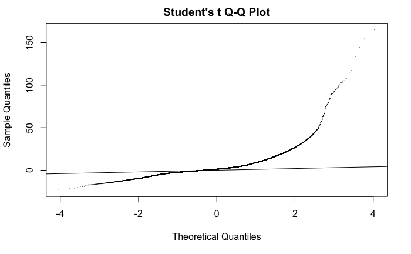

```r
qqt(fit$t, pch = 16, cex = 0.2); abline(0,1)
dev.off()
```

```r
# Print out plot here
qq.plot
```

[output not shown]

[output cut: 324 more lines]

Make a volcano plot and save to png

```r
# Create volcano plot
voc.plot <- volcanoplot(fit, main = "Volcano Plot")
# Save plot to png
png(file.path("plots", "volcano_plot_GSE71270.png"))
```

```r
voc.plot
```

[figure not shown]

```r
dev.off()
```

```r
# Print out the plot here
voc.plot
```

## 6) Write statistics to output results file

```r
readr::write_tsv(stats, file.path("results", "GSE71270_limma_results.tsv"))
```